# Tutorial 4

```r
library(ggplot2)

#For loops and the apply family of functions
squares = rep(NA, 10)
for (i in 1:10) {
  squares[i] = i^2
}
squares
```

```
##  [1]   1   4   9  16  25  36  49  64  81 100
```

```r
# Sapply
sapply(1:10, function(x)  x^2)
```

```
##  [1]   1   4   9  16  25  36  49  64  81 100
```

```r
# define our own function for sapply
#
areaCircle = function(r){
  return(pi * r^2)
}
sapply(1:10, areaCircle)
```

```
##  [1]   3.141593  12.566371  28.274334  50.265482  78.539816 113.097336
##  [7] 153.938040 201.061930 254.469005 314.159265
```

```r
pi*(1:10)^2
```

```
##  [1]   3.141593  12.566371  28.274334  50.265482  78.539816 113.097336
##  [7] 153.938040 201.061930 254.469005 314.159265
```

```r
listy = list(a = TRUE, b = c("a", "b", "c"), c = 10:100)
str(listy)
```

```
## List of 3
##  $ a: logi TRUE
##  $ b: chr [1:3] "a" "b" "c"
##  $ c: int [1:91] 10 11 12 13 14 15 16 17 18 19 ...
```

```r
length(listy)
```

```
## [1] 3
```

```r
sapply(listy, FUN = length)
```

```
##  a  b  c
##  1  3 91
```

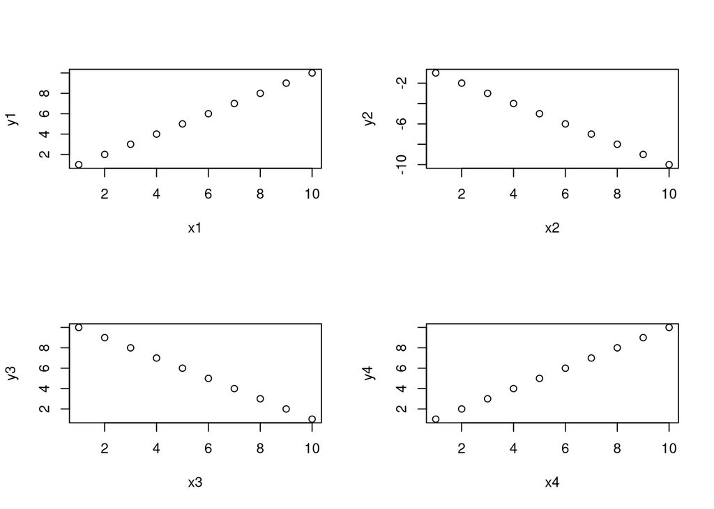

```r
# Sapply for creating plots
df1 = data.frame(x1 = 1:10, y1 = 1:10)
df2 = data.frame(x2 = 1:10, y2 = -1:-10)
df3 = data.frame(x3 = 1:10, y3 = 10:1)
df4 = data.frame(x4 = 1:10, y4 = 1:10)
my_list = list(df1, df2, df3, df4)
par(mfrow = c(2,2))
sapply(my_list, plot)
```

```r
# Apply
data(state)
states = as.data.frame(state.x77)
str(states)
```

```
## 'data.frame':    50 obs. of  8 variables:
##  $ Population: num  3615 365 2212 2110 21198 ...
##  $ Income    : num  3624 6315 4530 3378 5114 ...
##  $ Illiteracy: num  2.1 1.5 1.8 1.9 1.1 0.7 1.1 0.9 1.3 2 ...
##  $ Life Exp  : num  69 69.3 70.5 70.7 71.7 ...
##  $ Murder    : num  15.1 11.3 7.8 10.1 10.3 6.8 3.1 6.2 10.7 13.9 ...
##  $ HS Grad   : num  41.3 66.7 58.1 39.9 62.6 63.9 56 54.6 52.6 40.6 ...
##  $ Frost     : num  20 152 15 65 20 166 139 103 11 60 ...
##  $ Area      : num  50708 566432 113417 51945 156361 ...
```

```r
# calculate the mean for each column
apply(states, 2, mean)
```

```
## Population     Income Illiteracy   Life Exp     Murder    HS Grad      Frost
##  4246.4200  4435.8000     1.1700    70.8786     7.3780    53.1080   104.4600
##       Area
## 70735.8800
```

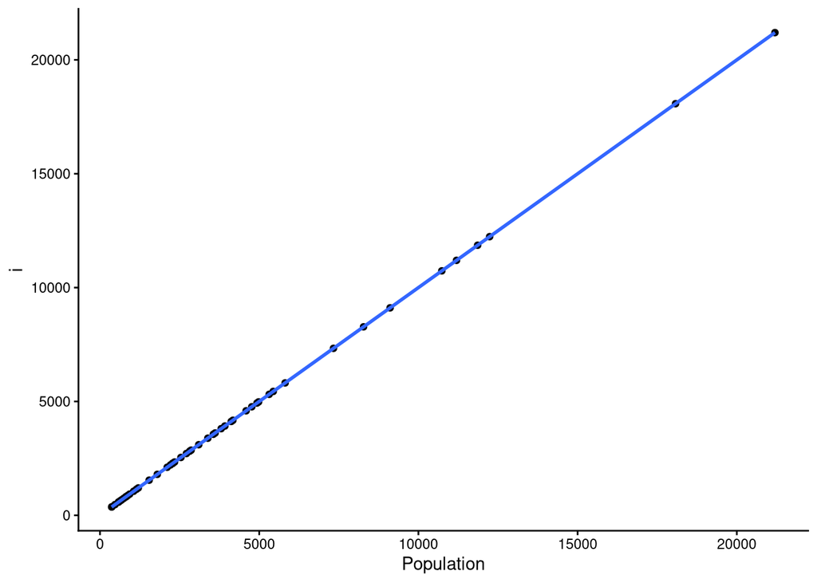

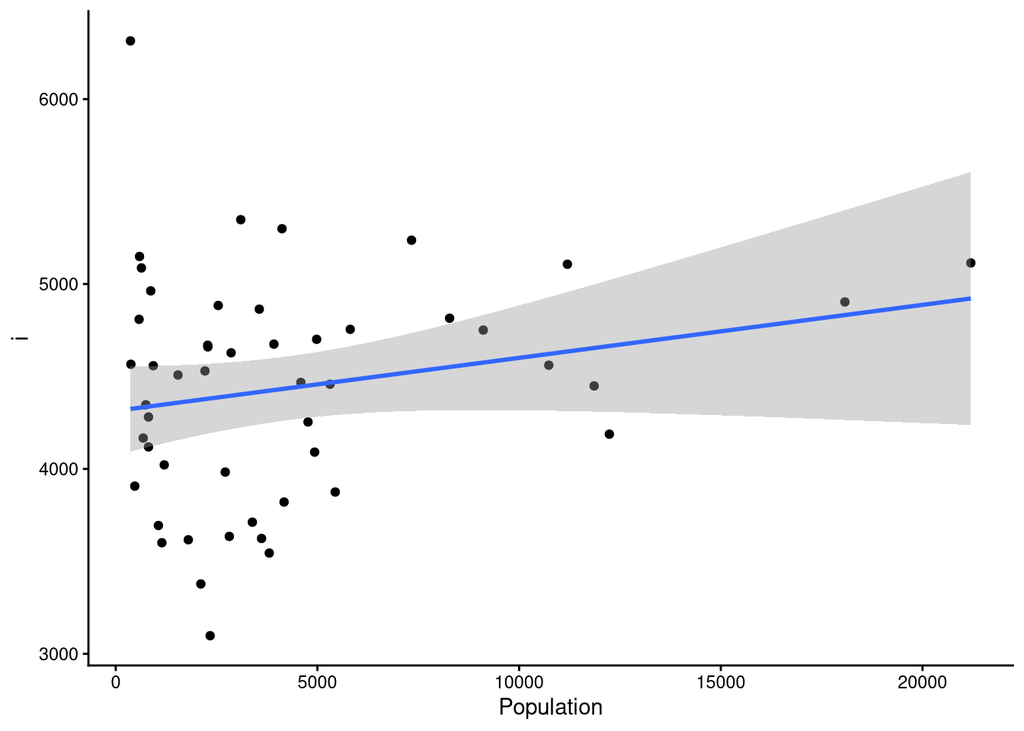

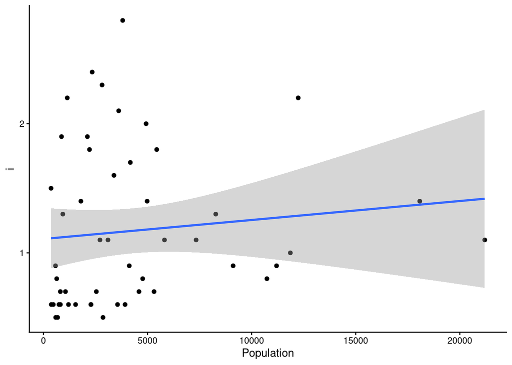

```
##
## $`Life Exp`
```

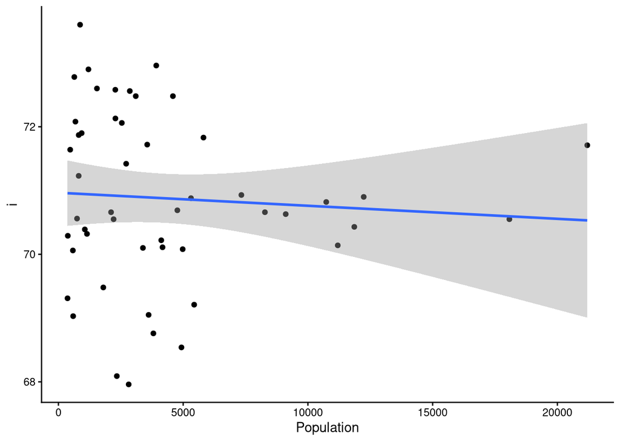

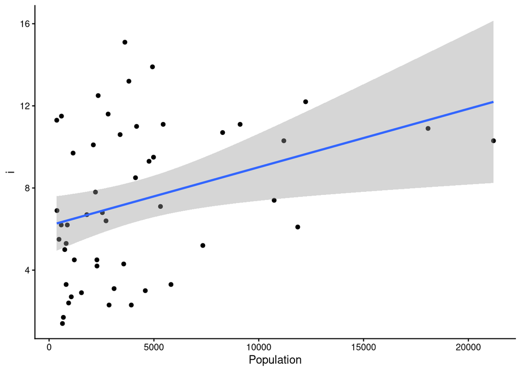

```
##
## $`HS Grad`
```

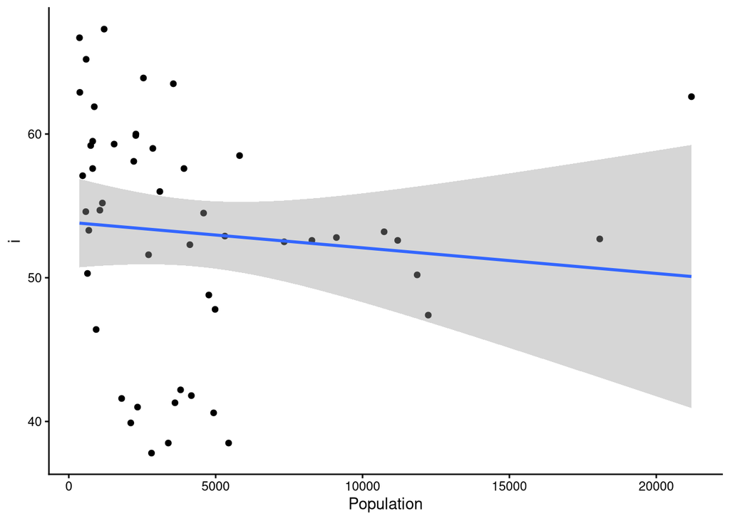

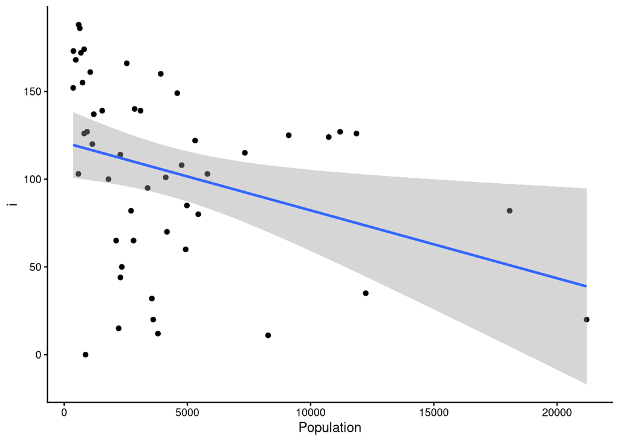

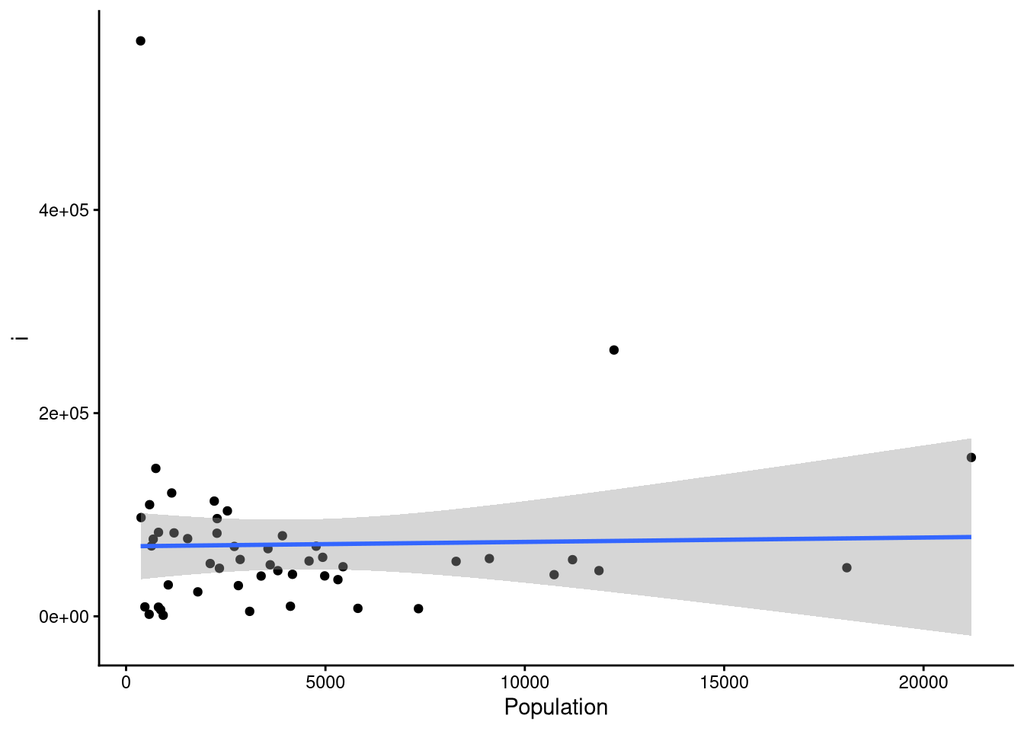

```r
# plot each column against Population in ggplot
apply(states, 2, FUN = function(i) ggplot(states, aes(x=Population, y = i))+geom_point()+geom_smooth(method="lm")+theme_classic())
```

```r
#calculate the sum across each row in states
apply(states, 1, sum)
```

```
##        Alabama         Alaska        Arizona       Arkansas     California
##       58094.55      573412.81      120312.25       57620.56      182838.71
##       Colorado    Connecticut       Delaware        Florida        Georgia
##      111500.46       13581.68        7604.76       67328.26       67280.04
##         Hawaii          Idaho       Illinois        Indiana           Iowa
##       12399.60       87872.27       72312.94       46121.58       63704.36
##         Kansas       Kentucky      Louisiana          Maine       Maryland
##       88987.58       46964.80       52419.96       35961.49       19544.92
##  Massachusetts       Michigan      Minnesota    Mississippi       Missouri
##       18632.73       70939.43       88178.46       52908.99       78253.59
##        Montana       Nebraska         Nevada  New Hampshire     New Jersey
##      150970.36       82809.40      115962.23       14426.83       20335.73
##     New Mexico       New York North Carolina   North Dakota           Ohio
##      126414.42       71027.55       58314.61       75308.28       56527.22
##       Oklahoma         Oregon   Pennsylvania   Rhode Island South Carolina
##       75692.52      103308.93       61528.73        6787.00       36860.66
##   South Dakota      Tennessee          Texas           Utah        Vermont
##       81102.58       49516.61      278726.70       87603.30       13948.84
##       Virginia     Washington  West Virginia      Wisconsin        Wyoming
##       49675.78       75165.12       29705.18       63800.68      102458.69
```

```r
# lapply
lapply(1:10, function(x)  x^2)
```

```
## [[1]]
## [1] 1
##
## [[2]]
## [1] 4
##
## [[3]]
## [1] 9
##
## [[4]]
## [1] 16
##
## [[5]]
## [1] 25
##
## [[6]]
## [1] 36
##
## [[7]]
## [1] 49
##
## [[8]]
## [1] 64
##
## [[9]]
## [1] 81
##
## [[10]]
## [1] 100
```

```r
sapply(1:10, function(x)  x^2, simplify = FALSE)
```

```
## [[1]]
## [1] 1
##
## [[2]]
## [1] 4
##
## [[3]]
## [1] 9
##
## [[4]]
## [1] 16
##
## [[5]]
## [1] 25
##
## [[6]]
## [1] 36
##
## [[7]]
## [1] 49
##
## [[8]]
## [1] 64
##
## [[9]]
## [1] 81
##
## [[10]]
## [1] 100
```

```r
sapply(1:10, function(x)  x^2)
```

```
##  [1]   1   4   9  16  25  36  49  64  81 100
```

```r
# tapply
str(states)
```

```
## 'data.frame':    50 obs. of  8 variables:
##  $ Population: num  3615 365 2212 2110 21198 ...
##  $ Income    : num  3624 6315 4530 3378 5114 ...
##  $ Illiteracy: num  2.1 1.5 1.8 1.9 1.1 0.7 1.1 0.9 1.3 2 ...
##  $ Life Exp  : num  69 69.3 70.5 70.7 71.7 ...
##  $ Murder    : num  15.1 11.3 7.8 10.1 10.3 6.8 3.1 6.2 10.7 13.9 ...
##  $ HS Grad   : num  41.3 66.7 58.1 39.9 62.6 63.9 56 54.6 52.6 40.6 ...
##  $ Frost     : num  20 152 15 65 20 166 139 103 11 60 ...
##  $ Area      : num  50708 566432 113417 51945 156361 ...
```

```r
tapply(states$Frost, state.region, mean)
```

```
##     Northeast         South North Central          West
##      132.7778       64.6250      138.8333      102.1538
```

```r
# nest apply statements
apply(states,
      2,
      function(x) tapply(x, state.region, mean))
```

```
##               Population   Income Illiteracy Life Exp    Murder  HS Grad
## Northeast       5495.111 4570.222   1.000000 71.26444  4.722222 53.96667
## South           4208.125 4011.938   1.737500 69.70625 10.581250 44.34375
## North Central   4803.000 4611.083   0.700000 71.76667  5.275000 54.51667
## West            2915.308 4702.615   1.023077 71.23462  7.215385 62.00000
##                  Frost      Area
## Northeast     132.7778  18141.00
## South          64.6250  54605.12
## North Central 138.8333  62652.00
## West          102.1538 134463.00
```

# Exercise 3: tapply and sapply

# Name: Nicolas Galgano

# Date: 11/5/2026

# Load state data

```r
data(state)
```

# this data is stored in a slightly different way than other datasets we’ve used so far

# run this line of code to avoid later confusion

```r
states = as.data.frame(state.x77)
```

# 1: What is the average population, income, and area of all 50 states ins the `states` dataset?

# Your code here:

```r
sapply(states[, c("Population", "Income", "Area")], mean)
```

```
## Population     Income       Area
##    4246.42    4435.80   70735.88
```

# 2. What is the average area of the states from different regions of the country?

# Hint: use the object state.region in your environment

# Your code here:

```r
tapply(states$Area, state.region, mean)
```

```
##     Northeast         South North Central          West
##      18141.00      54605.12      62652.00     134463.00
```

# 3. Plot a histogram for each column in the states data (Population, Income, Illiteracy etc.)

# Your code here:

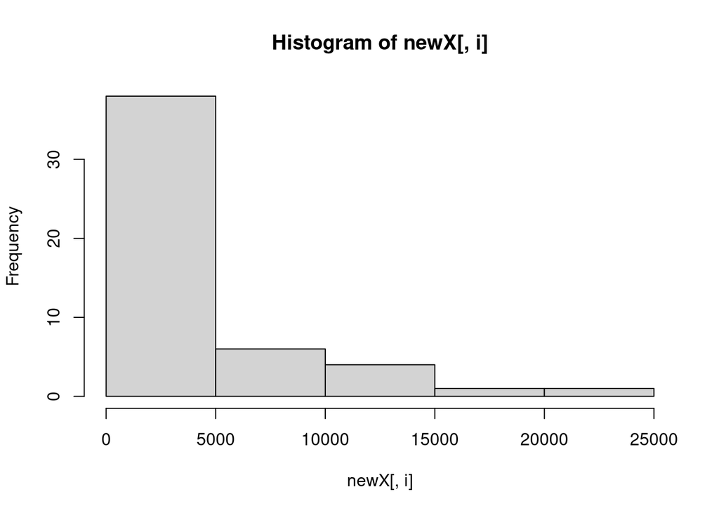

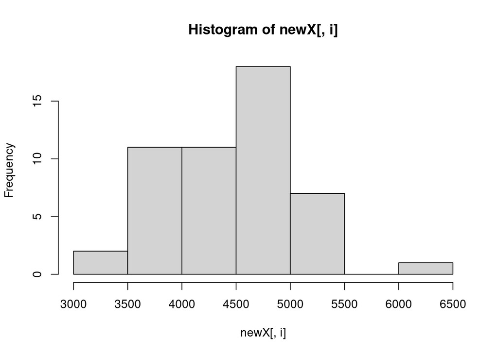

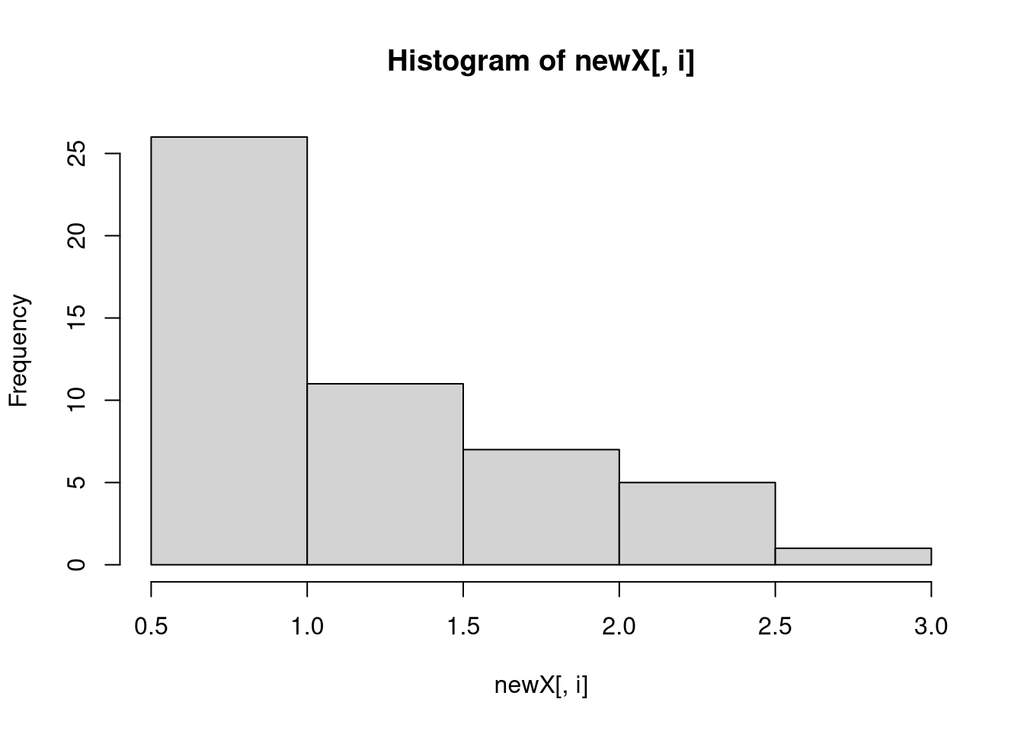

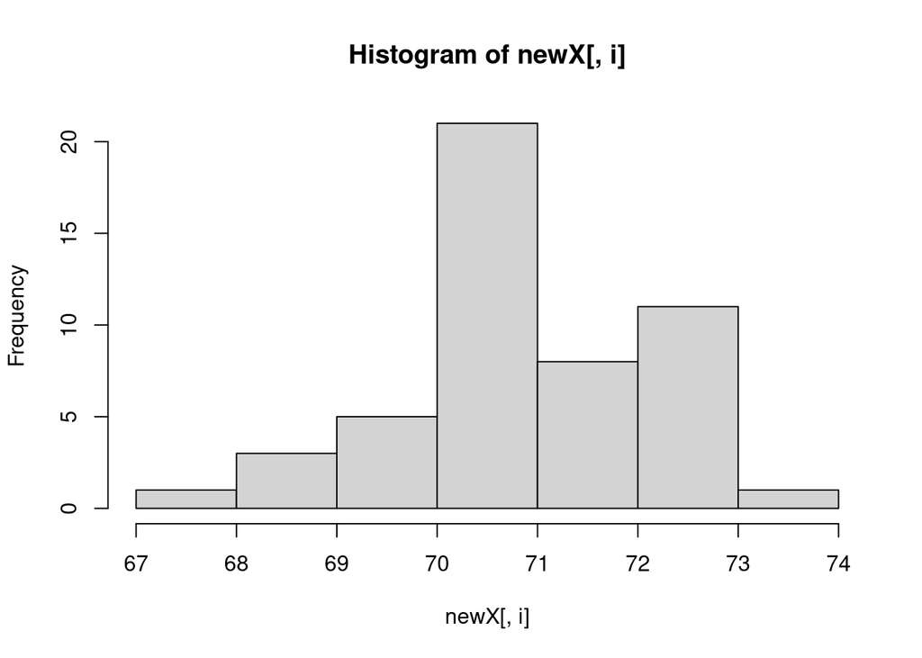

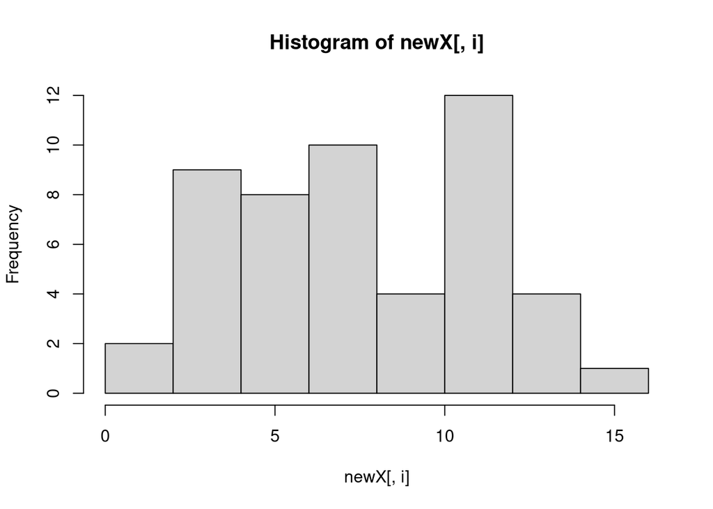

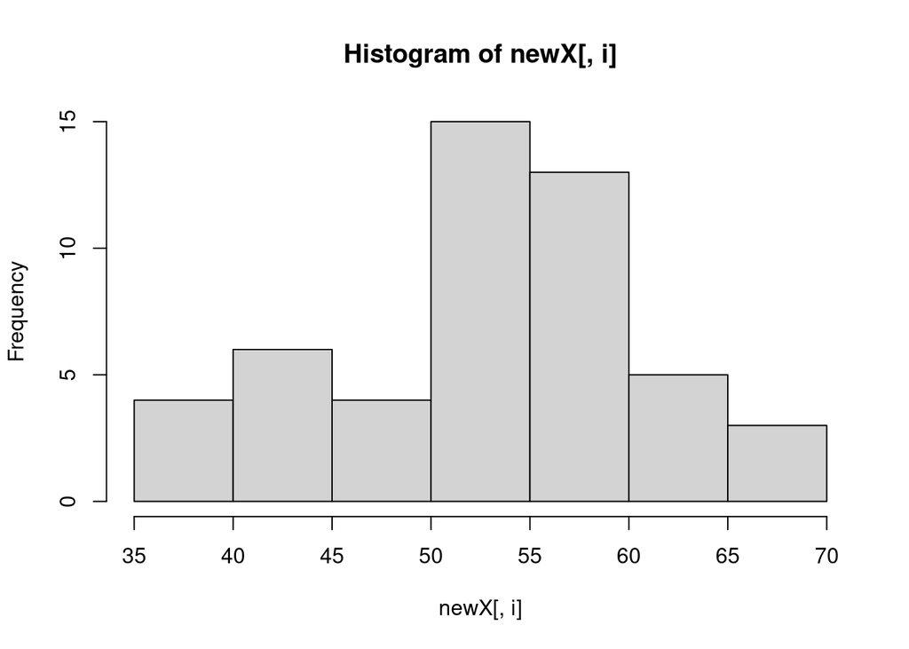

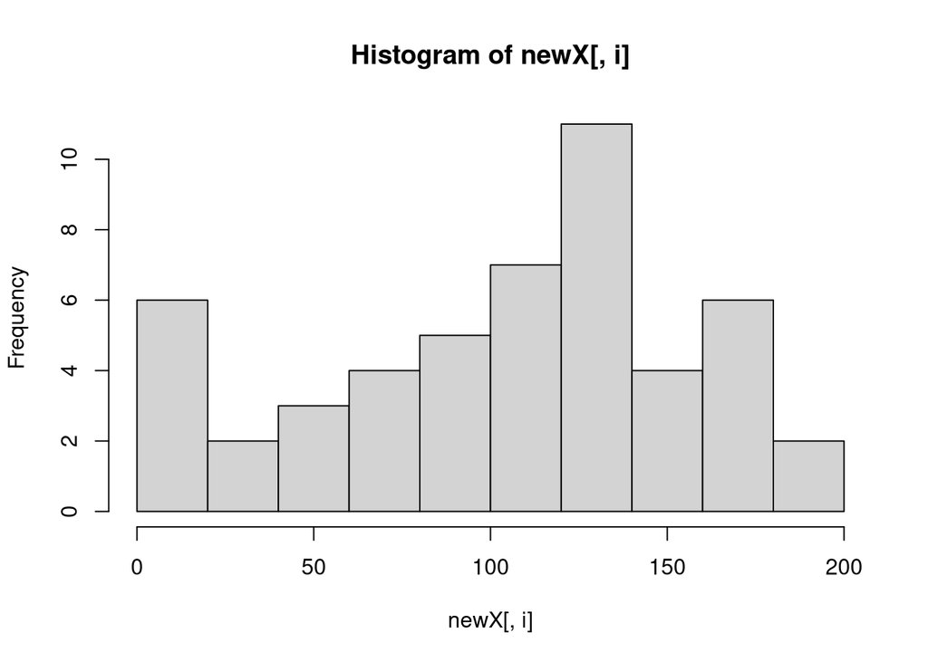

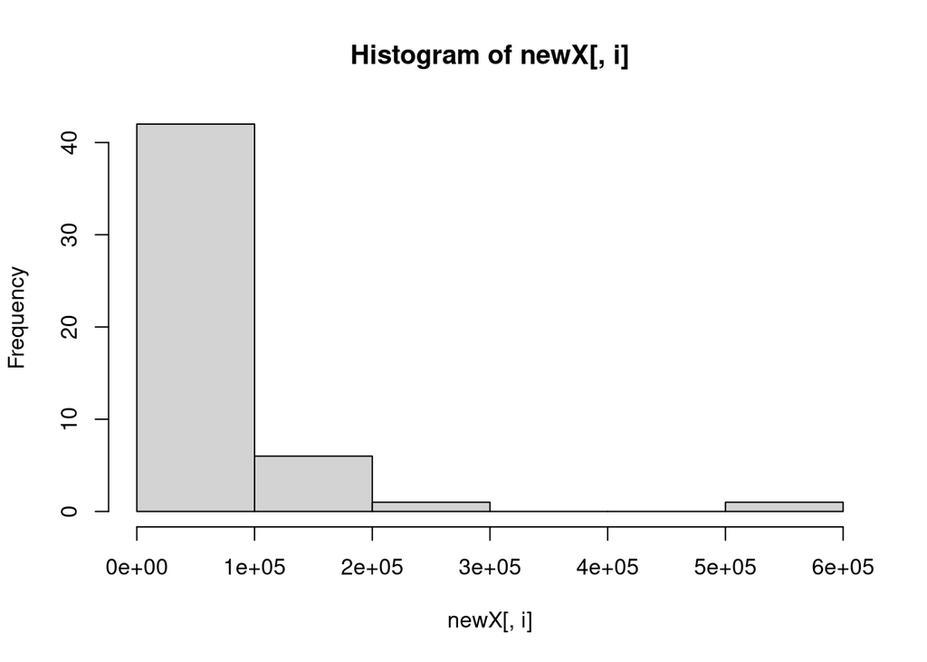

[output not shown]

[output cut: 120 more lines]

[output not shown]

```r
apply(states, 2, hist)
```

# 4. Let’s assume that we don’t want to live in a state with high illiteracy, high murder, and

# many freezing days; also assume that each of these factors contribute equally to our opinion

# (Illiteracy * Murder * Frost) = undesirable

# What 10 states should we avoid? # hint use prod(); and maybe order()

# Your code here:

```r
undesirable <- apply(states[, c("Illiteracy", "Murder", "Frost")], 1, prod)

head(sort(undesirable, decreasing = TRUE), 10)
```

```
##         Alaska     New Mexico South Carolina        Georgia       Kentucky
##        2576.40        2560.80        1734.20        1668.00        1611.20
## North Carolina    Mississippi      Tennessee       New York       Michigan
##        1598.40        1500.00        1309.00        1251.32        1248.75
```

# 5. Use sapply() to plot a histogram of the data below 4 times, in 4 different colors.

# For extra style, title the plot by it’s color, e.g. the red plot is titled “red”

# Your code here:

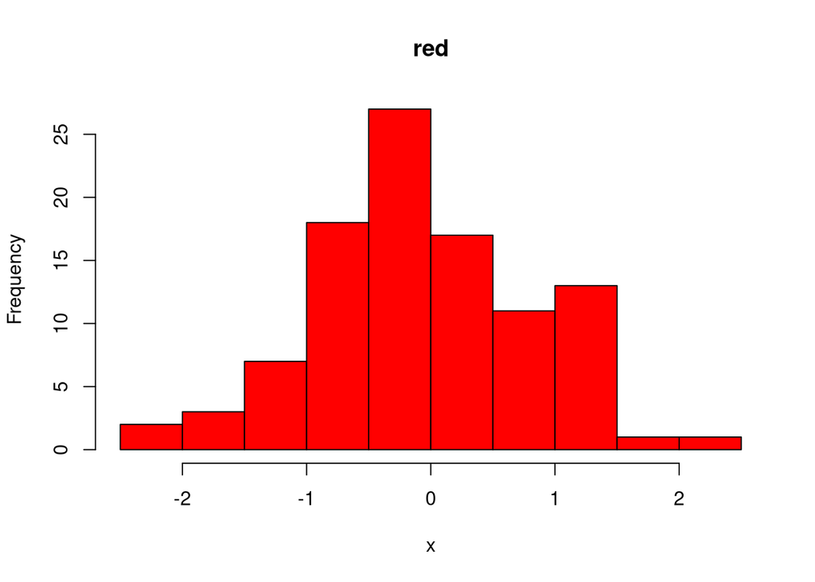

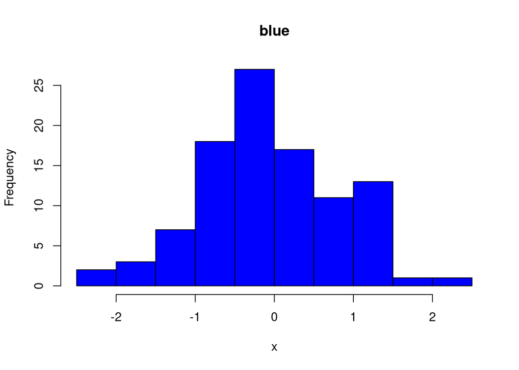

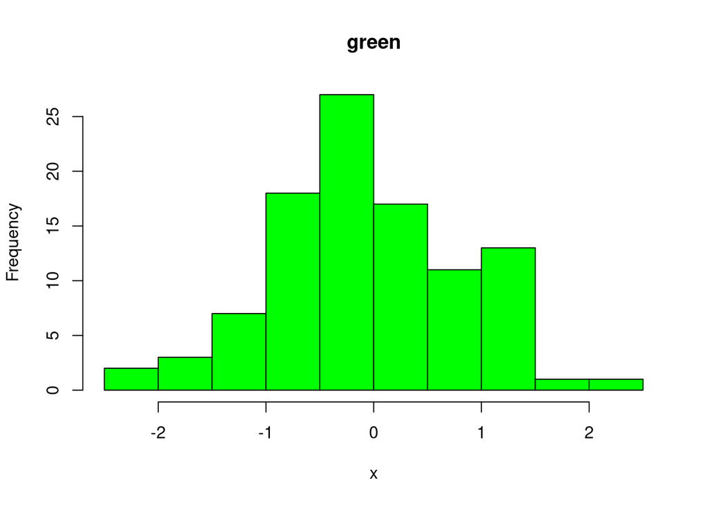

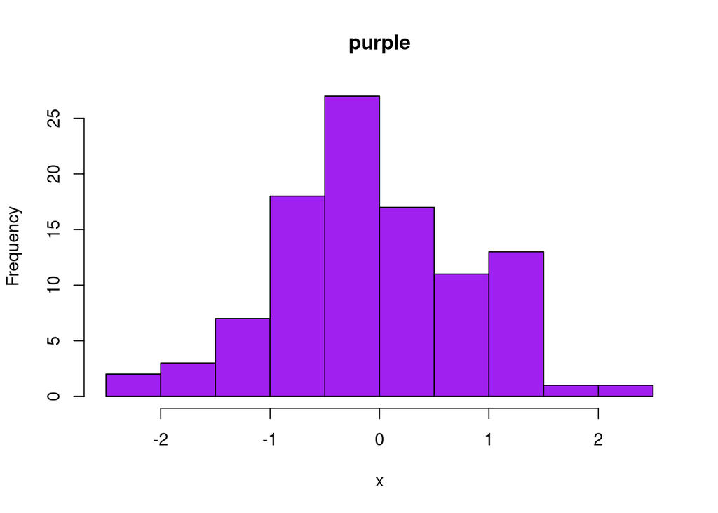

```
##          red        blue       green      purple
## breaks   numeric,11 numeric,11 numeric,11 numeric,11
## counts   integer,10 integer,10 integer,10 integer,10
## density  numeric,10 numeric,10 numeric,10 numeric,10
## mids     numeric,10 numeric,10 numeric,10 numeric,10
## xname    "x"        "x"        "x"        "x"
## equidist TRUE       TRUE       TRUE       TRUE
```

```r
colors <- c("red", "blue", "green", "purple")
# No data provided so I made my own

x <- rnorm(100)

sapply(colors, function(col) {
  hist(x, col = col, main = col)
})
```

# 6. Standardize all the variables in the states dataset and save your answer to a new

# dataframe, states_standardized

# Hint: to standardize a variable, you subtract the mean and divide by the standard deviation (sd)

# Your code here:

```r
states_standardized <- as.data.frame(apply(states, 2, function(x) (x - mean(x)) / sd(x)))
```

# 7. Create a histogram again for each variable in the states data, but this time label each

# histogram with the variable names when you plot

# Hint: instead of using apply to iterate over the columns themselves, you can often iterate

# over the column names with sapply

# Your code here:

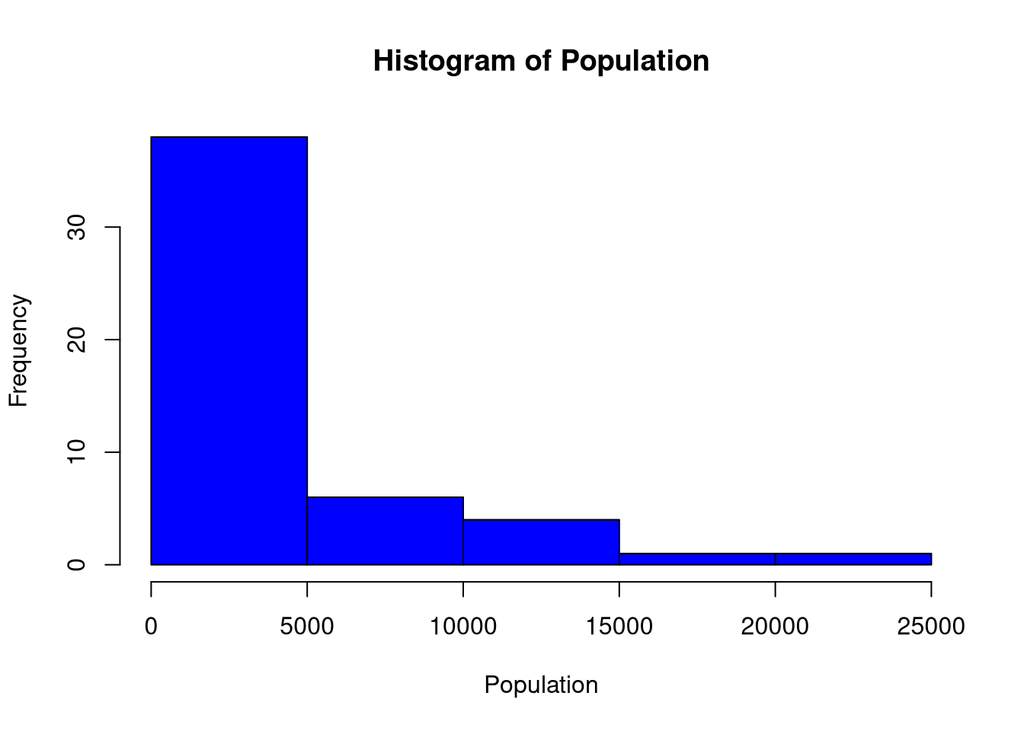

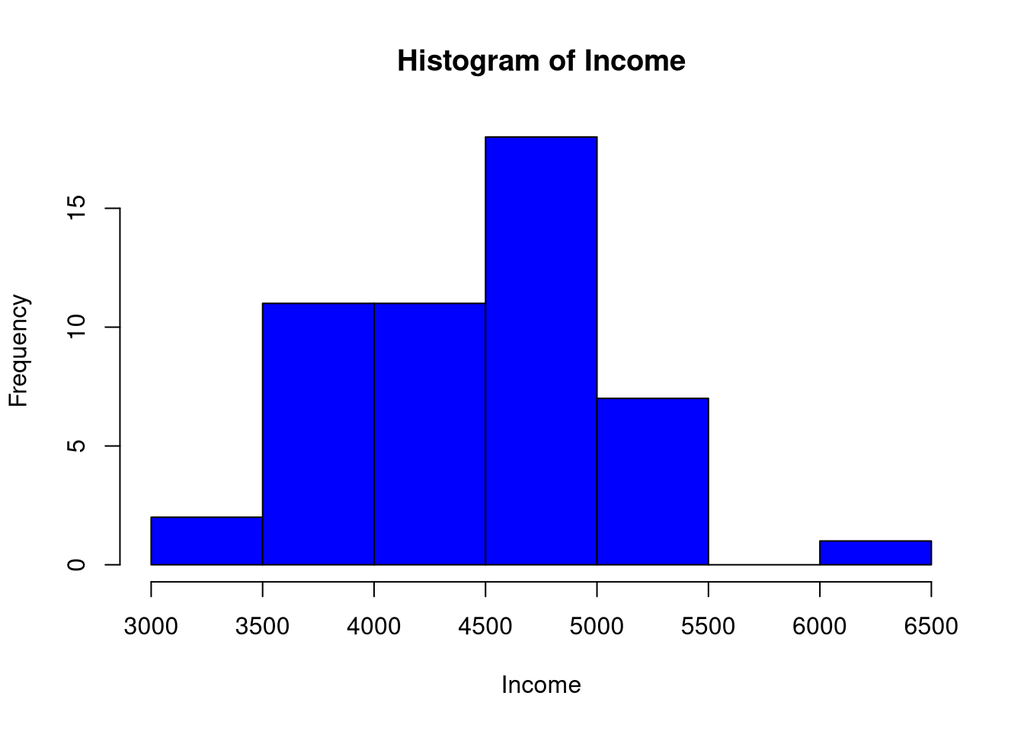

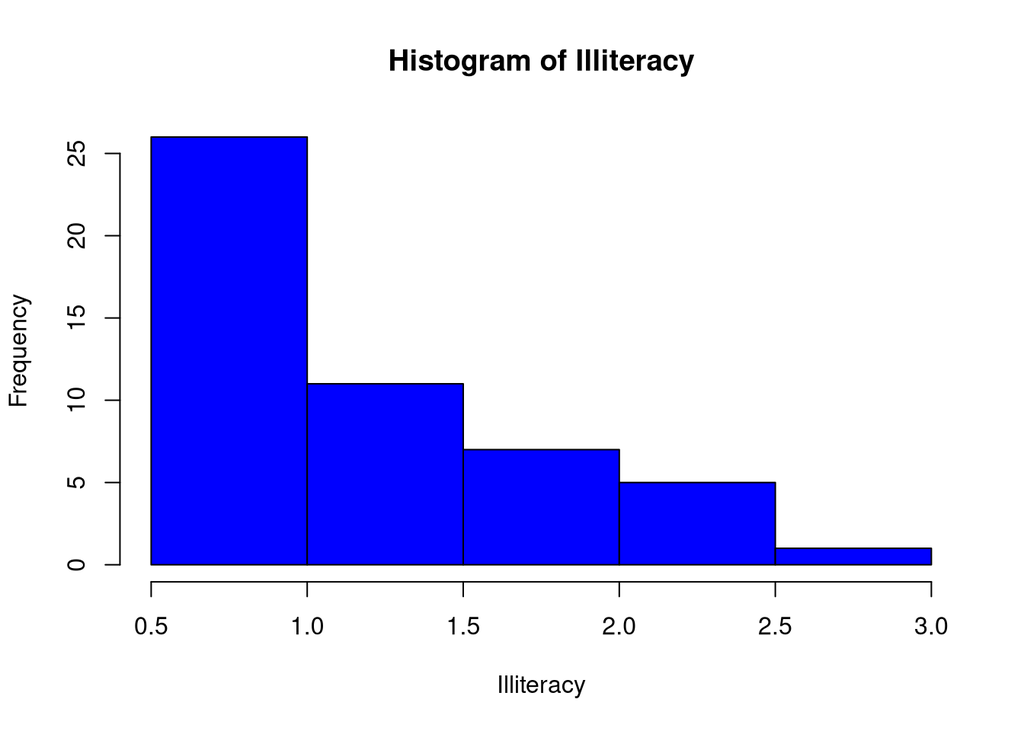

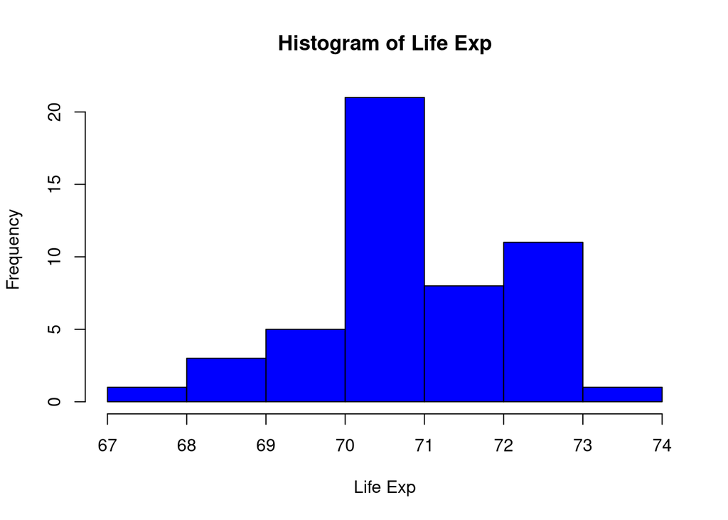

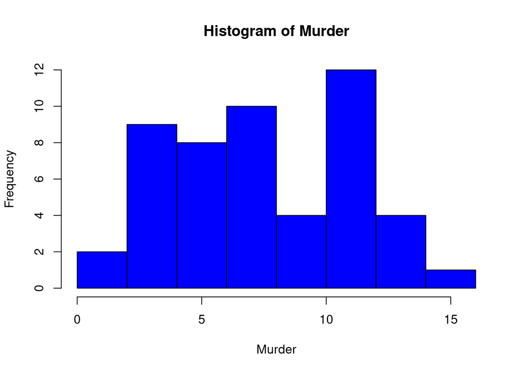

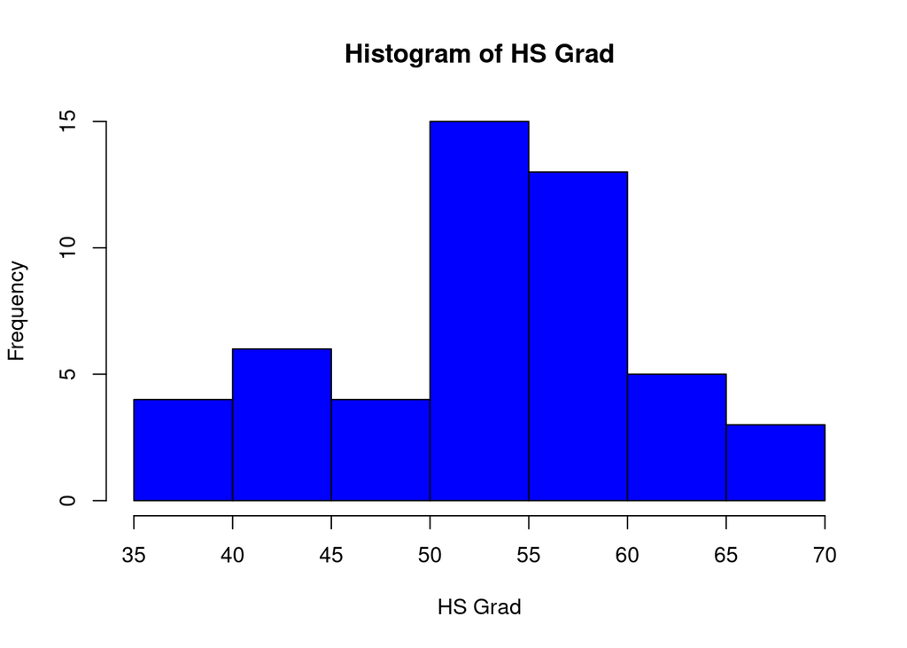

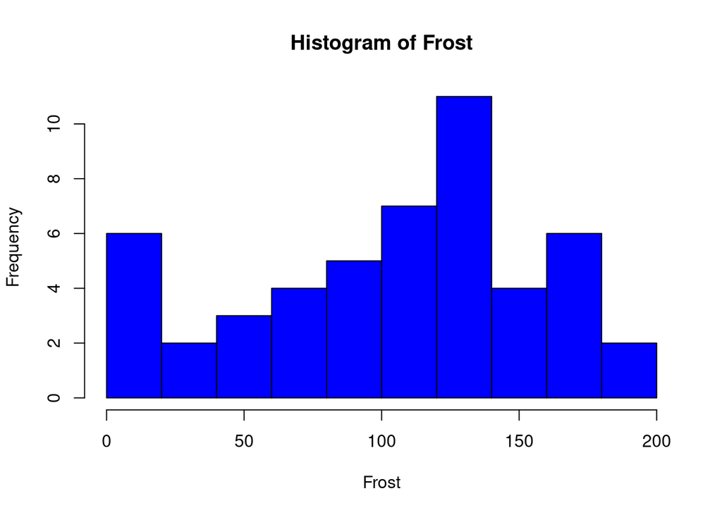

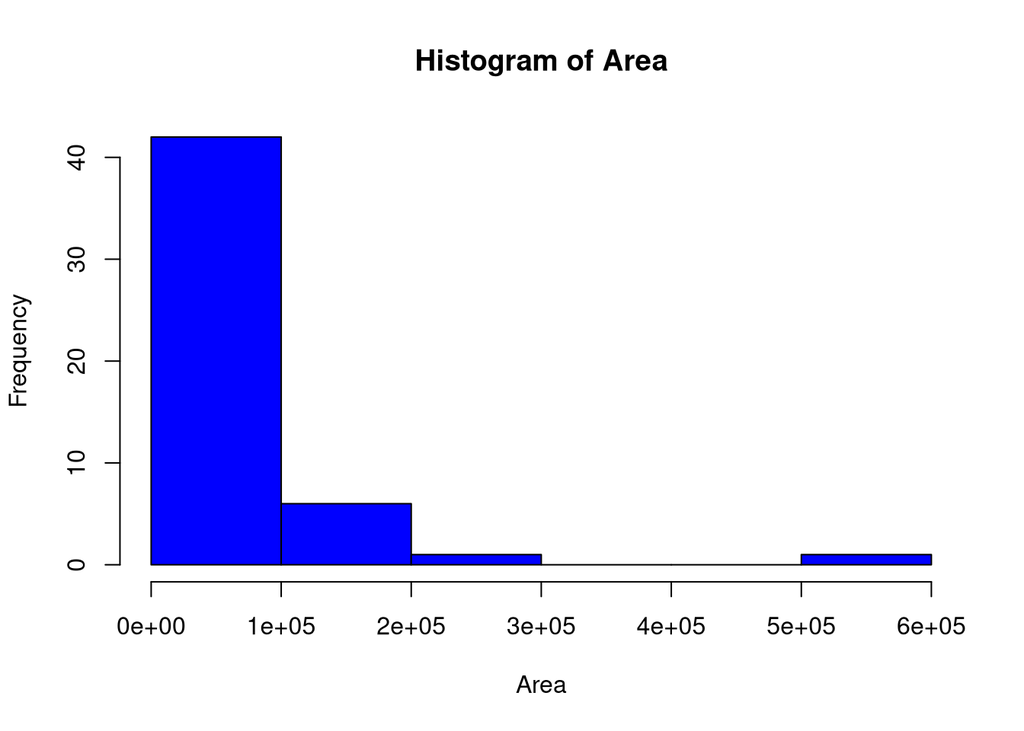

```
##          Population      Income          Illiteracy      Life Exp
## breaks   numeric,6       integer,8       numeric,6       integer,8
## counts   integer,5       integer,7       integer,5       integer,7
## density  numeric,5       numeric,7       numeric,5       numeric,7
## mids     numeric,5       numeric,7       numeric,5       numeric,7
## xname    "states[[col]]" "states[[col]]" "states[[col]]" "states[[col]]"
## equidist TRUE            TRUE            TRUE            TRUE
##          Murder          HS Grad         Frost           Area
## breaks   numeric,9       integer,8       numeric,11      numeric,7
## counts   integer,8       integer,7       integer,10      integer,6
## density  numeric,8       numeric,7       numeric,10      numeric,6
## mids     numeric,8       numeric,7       numeric,10      numeric,6
## xname    "states[[col]]" "states[[col]]" "states[[col]]" "states[[col]]"
## equidist TRUE            TRUE            TRUE            TRUE
```

```r
sapply(names(states), function(col) {
  hist(states[[col]], main = paste("Histogram of", col), xlab = col, col = "blue")
})
```